# Income and Renewable Heating Adoption in Switzerland

Yannik Zimmermann & Birk Diener

2026-05-20

## Motivation

Switzerland has committed to achieving net-zero greenhouse gas emissions by 2050, with the heating sector representing one of the largest remaining sources of fossil fuel consumption. Transitioning residential buildings away from oil and gas heating towards renewable alternatives such as heat pumps, solar thermal systems, and biomass is therefore a critical lever of the energy transition. However, adoption rates of renewable heating systems vary significantly across Swiss municipalities (bfs 2024). This project investigates a potential explanation for this heterogenous adoption pattern, namely whether a statistically measurable relationship exists between community-level income and the share of renewable heating systems installed.

## Project Aim

This project aims to quantify the relationship between median income at the municipality level and the share of buildings equipped with renewable heating systems across Swiss municipalities. The analysis will address two core research questions:

- Is there a statistically significant relationship between municipal-level financial capacity, measured through taxable income, and the share of residential buildings equipped with renewable heating systems across Swiss municipalities?
- To what extent is this relationship robust to structural characteristics of the building stock, namely the share of single-family houses and the age of the building stock, and to cantonal differences in subsidy programmes?

The analysis draws on the Federal Building and Dwellings Register (GWR) and ESTV municipal tax data. Given known data quality limitations in the GWR heating system entries, a systematic data recency assessment is integrated into the analysis prior to modelling. The findings will be visualised through choropleth maps and scatter plots to make spatial and socioeconomic patterns legible for a broader audience.

## Data Sources

Two datasets are used for this analysis, both openly available and joinable at the Swiss municipality level (BFS-Gemeindecode). The first is the Federal Building and Dwellings register (GWR), which records the primary heating energy, building category, and year of construction for every residential building in Switzerland. Key variables used in this analysis are the heating system type (GWAERZH1), the energy source (GENH1), the year of construction (GBAUJ), the information source of the heating entry (GWAERSCEH1), the last update date of the heating entry (GWAERDATH1), and the municipality code (GGDENR).

While the general availability of data to answer the research question is good, there is a significant challenge regarding the reliability of the heating system entries. The last comprehensive national update of this information took place as part of the Volkszählung 2000. Since then, municipal building departments are responsible for updating entries, primarily through building permit applications. As a result, data quality varies across municipalities, and heating systems installed without a building permit — such as most external air-source heat pumps — may not be recorded. We investigate this aspect further in the data preparation chapter.

## Approach

The analysis proceeds in four steps: First, GWR building data is aggregated to the municipality level to compute the share of residential buildings equipped with a renewable heating system as a fraction of all buildings with a recorded heating system entry. Renewable heating is defined as heat pump, solar thermal, or biomass combined with energy source. District heating is excluded from the primary definition as its adoption is structurally determined by local infrastructure rather than individual investment decisions, but is included in a sensitivity analysis. The share of pre-1980 buildings per municipality serves as the building age control variable.

Second, the municipal renewable heating share is joined to the ESTV income data using the BFS municipality code. Third, regression models are estimated using a stepwise approach: a baseline model with median income as the sole predictor, followed by successive addition of building structure controls (share of single-family houses, share of pre-1980 buildings), sociodemographic controls (municipal type, log population size), and cantonal fixed effects to absorb unobserved variation in subsidy programmes and building regulations. The municipal share of low-quality heating entries is included as a control variable throughout all model specifications. The stability of the income coefficient across specifications is reported.

Fourth, findings are visualized through choropleth maps showing the spatial distribution of renewable heating adoption and median income respectively.

## Data Preparation

Before proceeding to the analysis, the GWR building data is prepared and aggregated to the municipal level. The preparation process includes filtering for residential buildings, flagging renewable heating systems, and assessing the quality of the heating system entries.

Residential buildings are identified using two GWR variables. First, GKAT (building category) is restricted to codes 1020 (exclusively residential) and 1030 (residential with secondary use), excluding buildings without mostly residential use. Second, GSTAT (building status) is restricted to code 1004, retaining only buildings recorded as currently existing and excluding buildings under construction, demolished, or otherwise inactive. Together, these two filters define the analytical population of existing residential buildings on which all subsequent measures are computed.

```r
## 1. Read the GWR building data --------------------------------------------
# The file is tab-separated even though it ends in .csv. We only read the
# columns we actually use (the full file has ~50 columns and ~3.3 M rows).

buildings <- read_tsv(
  here("gwr", "gebaeude_batiment_edificio.csv"),
  col_select = c(GGDENR, GGDENAME, GDEKT,
                 GKAT, GKLAS, GSTAT, GBAUJ,
                 GWAERZH1, GENH1, GWAERSCEH1, GWAERDATH1),
  na = c("", "NA"),
  show_col_types = FALSE
)

## 2. Keep only existing residential buildings -----------------------------
# GKAT: 1020 = exclusively residential, 1030 = residential with side use
# GSTAT 1004 = the building actually exists today.

residential <- buildings %>%
  filter(GKAT %in% c(1020, 1030), GSTAT == 1004)


## 3. Flag each building --------------------------------------------------
# Renewable heating per the project brief:

residential <- residential %>%
  mutate(
    # Kein Heizsystem — 7500
    is_no_heatsystem = GENH1 == 7500,
    # Wärmepumpe Luft — 7501
    is_hp_air        = GENH1 == 7501,
    # Wärmepumpe Erde/Wasser — 751x
    is_hp_ground     = GENH1 %in% c(7510, 7511, 7512, 7513),
    # Fossil — 752x, 753x
    is_gas           = GENH1 == 7520,
    is_oil           = GENH1 == 7530,
    # Holz — 754x
    is_wood          = GENH1 %in% c(7540, 7541, 7542, 7543),
    # Abwärme — 755x
    is_waste_heat    = GENH1 == 7550,
    # Elektrizität — 756x
    is_electric      = GENH1 == 7560,
    # Solar thermisch — 757x
    is_solar         = GENH1 == 7570,
    # Fernwärme — 758x (Sensitivity Analysis)
    is_district      = GENH1 %in% c(7580, 7581, 7582),
    # Unbestimmt/Andere — 759x
    is_other         = GENH1 %in% c(7598, 7599),

    # Aggregierte Flags
    is_heatpump  = is_hp_air | is_hp_ground,
    is_renewable = is_heatpump | is_wood | is_solar |
                   is_waste_heat | is_no_heatsystem
  )

## 5. Aggregate to the municipality ---------------------------------------
# Renewable share is defined over buildings with a heating entry, so the
# denominator is sum(!is.na(GWAERZH1)), not n().

muni <- residential %>%
  group_by(bfs_id = GGDENR, municipality = GGDENAME, canton = GDEKT) %>%
  summarise(
    n_buildings     = n(),
    n_with_heating  = sum(!is.na(GWAERZH1)),
    renewable_share = sum(is_renewable)   / sum(!is.na(GWAERZH1)),
    .groups = "drop"
  )
```

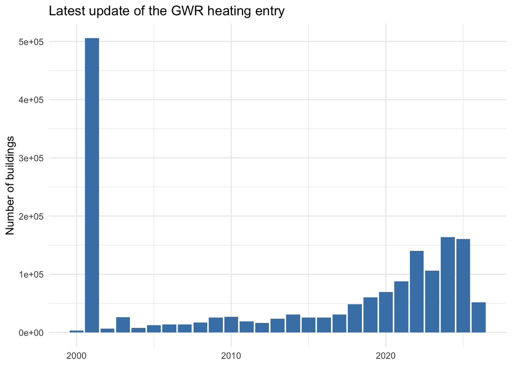

```r
## 4. Quick data-quality check --------------------------------------------
# When was the heating entry last updated? The brief notes this is a problem,
# many entries still go back to the 2000 census.

residential %>%
  mutate(year = as.integer(substr(GWAERDATH1, 1, 4))) %>%
  filter(!is.na(year), year >= 1990) %>%
  ggplot(aes(year)) +
  geom_bar(fill = "steelblue") +
  labs(title = "Latest update of the GWR heating entry",
       x = NULL, y = "Number of buildings") +
  theme_minimal()
```

Figure 1: Distribution of GWR heating entry update years for residential buildings in Switzerland

*Note: The figure shows the number of residential buildings by the year of their most recent heating system entry update (GWAERDATH1). Buildings with no recorded update date (n = 1,083,361) are excluded from the plot. The spike in 2001 reflects entries sourced from the Volkszählung 2000 (GWAERSCEH1 = 860), which represent the last comprehensive national update of heating system data. The subsequent increase from 2019 onwards reflects growing administrative activity following the 2017 revision of the GWR ordinance, which made heating data recording mandatory for new building permits.*

```r
estv_file <- here("estv", "statistik-dbst-np-gden-2022-normalfall.xlsx")

read_total <- function(sheet, value_name) {
  raw <- read_excel(
    estv_file, sheet = sheet, skip = 2,
    col_types = c("text", "text", "numeric", "text", rep("numeric", 11)),
    na = c("", "NA", "-")                    # <- '-' ergänzt
  )
  names(raw)[1:4]       <- c("canton_id", "canton_name", "bfs_id", "muni_name")
  names(raw)[ncol(raw)] <- "total"
  raw %>%
    filter(!is.na(bfs_id)) %>%
    select(bfs_id, !!value_name := total)
}

counts <- read_total("511", "n_taxpayers")
sums   <- read_total("512", "sum_taxable")

income <- counts %>%
  left_join(sums, by = "bfs_id") %>%
  mutate(mean_taxable = sum_taxable / n_taxpayers)
```

To prepare the data for the regression analysis, the building-level flags are extended with a low-quality marker, a single-family-house flag, and a pre-1980 construction flag. The municipal aggregation is then re-computed to add three structural control variables (`low_quality_share`, `sfh_share`, `pre1980_share`) and an alternative renewable share that includes district heating buildings in the numerator (`renewable_share_dh`) for the sensitivity analysis. The aggregated municipal table is joined with the ESTV income data on the BFS municipality code. Log transformations are applied to the mean taxable income (`log_income`) and to the building count (`log_pop`, used as a proxy for municipality size since no separate population variable is available from the GWR). Municipalities are further classified into three size groups (`rural`, `semi-urban`, `urban`) based on tertiles of `n_buildings`. To improve readability of all tables and plots, canton numeric codes are mapped to their standard two-letter abbreviations.

```r
## 1. Additional building-level flags --------------------------------------
# Low quality: heating entry is from the 2000 census (GWAERSCEH1 == 860) or
# has no recorded update date at all (is.na(GWAERDATH1)).
# SFH: GKLAS == 1110 (single-family house).
# Pre-1980: construction year before 1980. NAs in GBAUJ count as FALSE.

residential <- residential %>%
  mutate(
    is_lowqual = GWAERSCEH1 %in% 860 | is.na(GWAERDATH1),
    is_sfh     = !is.na(GKLAS) & GKLAS == 1110,
    is_pre1980 = !is.na(GBAUJ) & GBAUJ < 1980
  )

## 2. Re-aggregate to the municipality with all controls ------------------

muni <- residential %>%
  group_by(bfs_id = GGDENR, municipality = GGDENAME, canton_id = GDEKT) %>%
  summarise(
    n_buildings        = n(),
    n_with_heating     = sum(!is.na(GWAERZH1)),
    renewable_share    = sum(is_renewable)                 / sum(!is.na(GWAERZH1)),
    renewable_share_dh = sum(is_renewable | is_district)   / sum(!is.na(GWAERZH1)),
    low_quality_share  = sum(is_lowqual)                   / sum(!is.na(GWAERZH1)),
    sfh_share          = sum(is_sfh)                       / n(),
    pre1980_share      = sum(is_pre1980)                   / n(),
    .groups = "drop"
  )
# `muni` now has one row per municipality, with the renewable share, the
# alternative renewable share including district heating, and the three
# control variables for the regression.

## 3. Rename canton column ------------------------------------------------
# GDEKT already contains two-letter canton abbreviations (ZH, BE, etc.)

muni <- muni %>%
  rename(canton = canton_id)

## 4. Join with ESTV income, add log / categorical variables --------------

df <- muni %>%
  left_join(income %>% select(bfs_id, mean_taxable), by = "bfs_id") %>%
  mutate(
    log_income = log(mean_taxable),
    log_pop    = log(n_buildings),
    muni_type  = factor(
      ntile(n_buildings, 3),
      levels = 1:3,
      labels = c("rural", "semi-urban", "urban")
    )
  )
# `df` is the analysis frame: one row per municipality with renewable_share
# (and renewable_share_dh), the income predictor (log_income), and all controls.

## 5. Filter very small municipalities and missing predictors -------------
# Municipalities with fewer than 20 buildings with a heating entry produce
# unstable shares and are dropped, as are rows missing income or share.

n_before <- nrow(df)
df <- df %>%
  filter(n_with_heating >= 20,
         !is.na(log_income),
         !is.na(renewable_share)) %>%
  mutate(
    # Recreate muni_type based on post-filtered data to ensure all levels have observations
    muni_type = factor(
      ntile(n_buildings, 3),
      levels = 1:3,
      labels = c("rural", "semi-urban", "urban")
    ),
    canton = factor(canton)
  )
n_after   <- nrow(df)
n_dropped <- n_before - n_after
```

After filtering, 1288 municipalities are retained out of 2110 (822 dropped, predominantly small alpine or commuter municipalities with fewer than 20 buildings recorded with a heating entry).

## Exploratory Visualisations

Before estimating any regression model, the analytical data is explored visually. The five figures below answer four questions in order: (i) does the municipal renewable share have enough variance to be worth modelling, (ii) does municipal income visibly co-move with the renewable share in the raw data, (iii) is the GWR data-quality concern visible at the municipal level, and (iv) do the two spatial patterns (income and renewable adoption) look similar or different across Switzerland? The point is to build intuition for the data before any model is fit, so the regression results can be sanity-checked against the visual evidence.

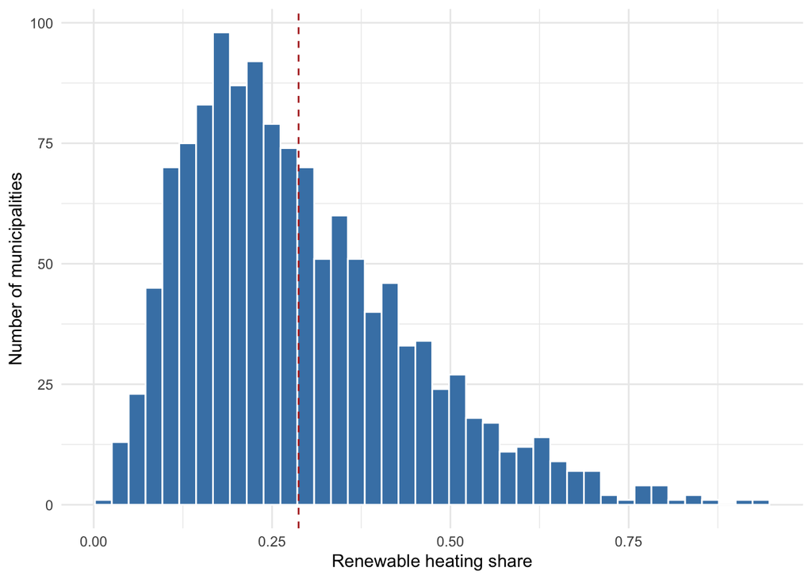

Figure 2: Distribution of the renewable heating share across Swiss municipalities. The unit is the fraction of residential buildings with a recorded heating entry. The dashed red line marks the national mean across municipalities.

```r
p2 <- ggplot(df, aes(x = renewable_share)) +
  geom_histogram(bins = 40, fill = "steelblue", colour = "white") +
  geom_vline(aes(xintercept = mean(renewable_share, na.rm = TRUE)),
             linetype = "dashed", colour = "firebrick") +
  labs(x = "Renewable heating share",
       y = "Number of municipalities") +
  theme_minimal()
p2
```

The histogram in Figure 2 confirms that the renewable share is far from degenerate. Municipal values range from roughly 1% to 94%, with the national mean (dashed red line) at about 28.7% and the median at 25.6%. The bulk of the distribution sits below the mean, with a tail of municipalities at higher renewable shares pulling the mean upwards. This skew is consistent with renewable adoption being concentrated in a subset of municipalities rather than spread uniformly, which is exactly the heterogeneity the regression is intended to explain.

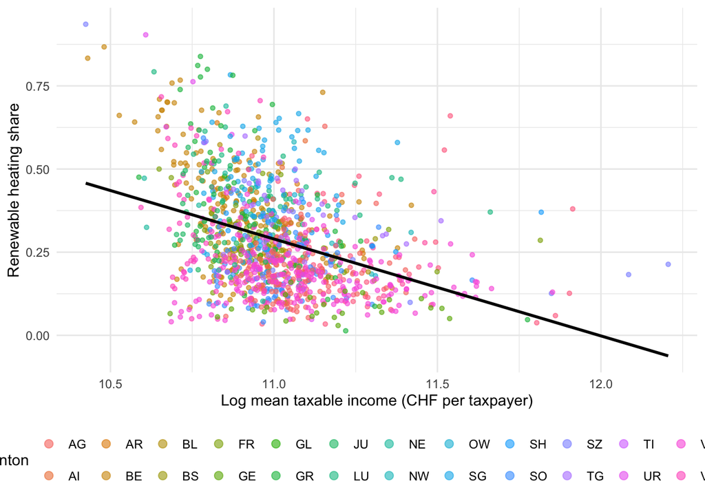

Figure 3: Mean taxable income (log) vs. renewable heating share. Each dot is one municipality, coloured by canton. The black line is an OLS fit across all municipalities.

```r
p3 <- ggplot(df, aes(x = log_income, y = renewable_share)) +
  geom_point(aes(colour = canton), alpha = 0.6, size = 1.2) +
  geom_smooth(method = "lm", se = FALSE, colour = "black") +
  labs(x = "Log mean taxable income (CHF per taxpayer)",
       y = "Renewable heating share",
       colour = "Canton") +
  theme_minimal() +
  theme(legend.position = "bottom") +
  guides(colour = guide_legend(nrow = 2, override.aes = list(size = 2.5)))
p3
```

Figure 3 is the key descriptive figure for the main research question, and it is already surprising. The black OLS line summarises the raw bivariate relationship between log income and the renewable share before any controls are added, and the slope is clearly *negative*: higher-income municipalities tend to have a *lower* renewable heating share. This runs against the simple “more money, more green investment” intuition the project started from, and the rest of the analysis is about figuring out whether this negative gradient is a genuine within-canton effect or an artefact of urban-rural sorting. The colour coding by canton helps see whether the pattern is driven by a few outlier cantons or holds broadly across the country, and a handful of cantons cluster visibly above or below the line, which is exactly the kind of cantonal heterogeneity that motivates the Model 4 fixed-effects specification.

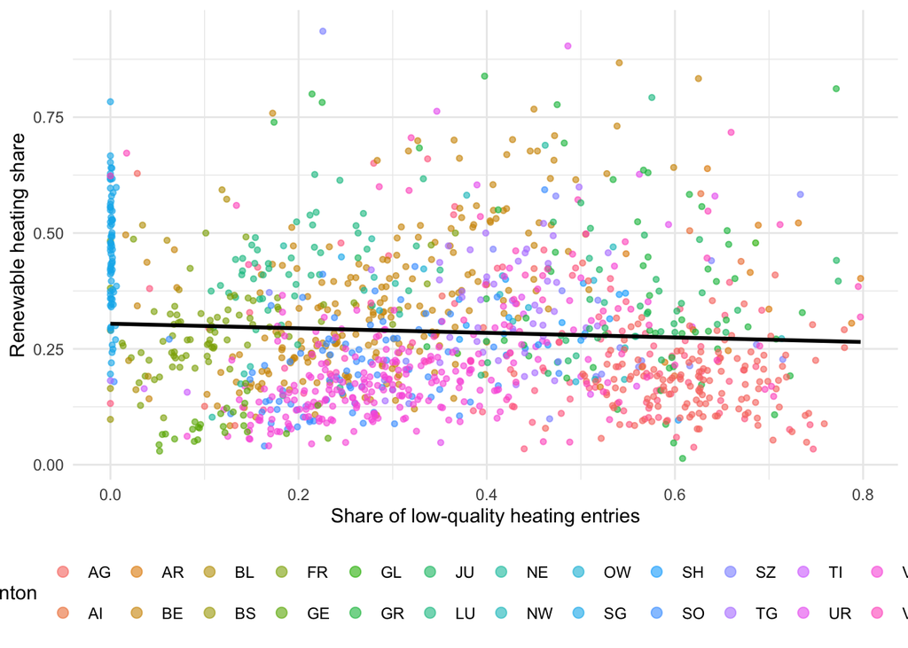

```r
p4 <- ggplot(df, aes(x = low_quality_share, y = renewable_share)) +
  geom_point(aes(colour = canton), alpha = 0.6, size = 1.2) +
  geom_smooth(method = "lm", se = FALSE, colour = "black") +
  labs(x = "Share of low-quality heating entries",
       y = "Renewable heating share",
       colour = "Canton") +
  theme_minimal() +
  theme(legend.position = "bottom") +
  guides(colour = guide_legend(nrow = 2, override.aes = list(size = 2.5)))
p4
```

```r
library(sf)

# Swiss municipality polygons. The cached file is produced from the swisstopo
# swissBOUNDARIES3D dataset and stored under data-derived/municipalities.gpkg.
# If the shapefile's BFS code variable is named differently, adjust the join
# key (currently expected: `bfs_id`).

muni_polygons <- st_read(
  here("data-derived", "municipalities.gpkg"),
  quiet = TRUE
) %>%
  st_zm()

map_data <- muni_polygons %>%
  left_join(df, by = "bfs_id")
# `map_data` is the sf object containing geometry plus all df columns.
```

Figures 5 and 6 then move from the scatter view to the spatial view. They show the same data twice, once shaded by renewable adoption and once by mean taxable income, so they can be read in parallel.

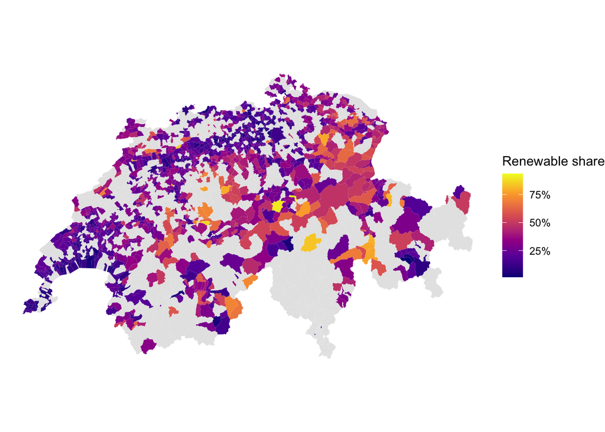

Figure 5: Choropleth map of the municipal renewable heating share. Municipalities dropped from the analysis appear grey.

```r
p5 <- ggplot(map_data) +
  geom_sf(aes(fill = renewable_share), colour = NA) +
  scale_fill_viridis_c(option = "plasma",
                       labels = scales::label_percent(),
                       na.value = "grey90") +
  coord_sf() +
  labs(fill = "Renewable share") +
  theme_void()
p5
```

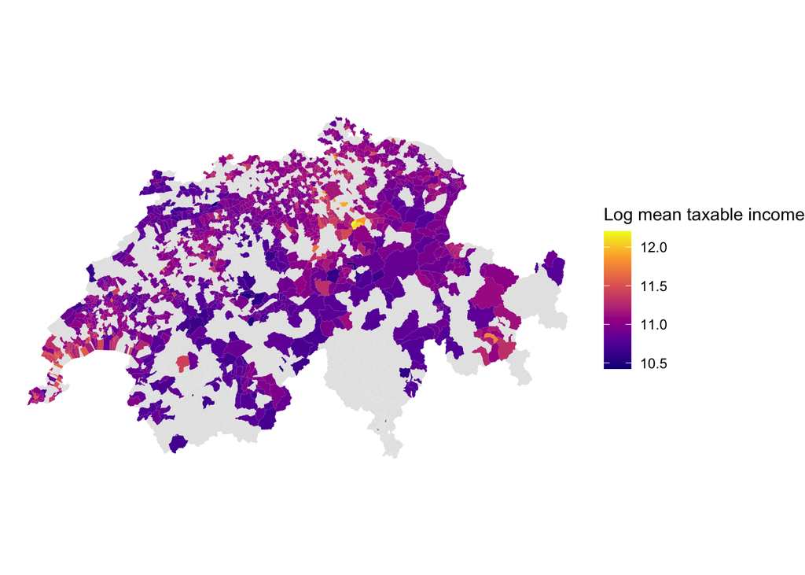

Figure 6: Choropleth map of the municipal mean taxable income (log scale). Higher values indicate higher mean taxable income per taxpayer.

```r
p6 <- ggplot(map_data) +
  geom_sf(aes(fill = log_income), colour = NA) +
  scale_fill_viridis_c(option = "plasma",
                       na.value = "grey90") +
  coord_sf() +
  labs(fill = "Log mean taxable income") +
  theme_void()
p6
```

Comparing the two maps gives the spatial analogue of the negative slope in Figure 3, and the inversion is visible at a glance. The bright (high-income) areas in Figure 6 cluster around the Zürich-Zug-Schwyz axis and around the Genfersee, that is, the urban Mittelland. The bright (high-renewable) areas in Figure 5, by contrast, sit in central and Alpine cantons (parts of Bern, the inner Cantons, Graubünden, Wallis) and in some peri-urban rural belts, that is, exactly the places where Figure 6 is darker. The mechanical reading: urban high-income municipalities tend to have district heating, multi-family stock, and older protected building cores that are harder to convert; Alpine and rural municipalities have more single-family houses and a long tradition of wood heating, both of which lift the renewable share. This urban-rural sorting is precisely what makes the bivariate income slope look negative, and is what the cantonal fixed effects in Model 4 are partly trying to absorb. Grey municipalities are those dropped by the `n_with_heating >= 20` filter or absent from the polygon vintage, and should not be over-interpreted.

## Analysis

The analysis follows a deliberate funnel: building on the visual exploration above (in particular the *negative* bivariate slope in Figure 3 and the surprisingly weak data-quality association in Figure 4), the relationship is now quantified in a series of nested regressions that progressively rule out alternative explanations, then stress-tested by changing the definition of the dependent variable, and finally checked against the OLS assumptions. The motivation is that the negative correlation between municipal income and renewable adoption could reflect almost anything that comes bundled with income at the municipal level (older urban building stock, more multi-family housing, more district heating, cantonal subsidy regimes), so each modelling step is designed to isolate the part of the relationship that survives the addition of a specific group of controls.

(Note: no random operations are used in this analysis. The tertile cut points for `muni_type` use the deterministic `dplyr::ntile()`, so a `set.seed()` call would have no effect and is omitted.)

### Descriptive Statistics

```r
library(tidyr)

desc_stats <- df %>%
  select(renewable_share, log_income, low_quality_share, sfh_share, pre1980_share) %>%
  pivot_longer(everything(), names_to = "variable", values_to = "value") %>%
  group_by(variable) %>%
  summarise(
    mean   = mean(value,   na.rm = TRUE),
    median = median(value, na.rm = TRUE),
    sd     = sd(value,     na.rm = TRUE),
    min    = min(value,    na.rm = TRUE),
    max    = max(value,    na.rm = TRUE),
    .groups = "drop"
  )
# `desc_stats` is a tidy summary table of central tendency and spread.

knitr::kable(desc_stats, digits = 2,
             caption = "Table 1: Summary statistics for the key analysis variables across Swiss municipalities.")
```

Table 1: Summary statistics for the key analysis variables across Swiss municipalities.

| variable | mean | median | sd | min | max |
| --- | --- | --- | --- | --- | --- |
| log_income | 11.01 | 10.99 | 0.20 | 10.42 | 12.21 |
| low_quality_share | 0.35 | 0.33 | 0.20 | 0.00 | 0.80 |
| pre1980_share | 0.21 | 0.04 | 0.24 | 0.00 | 0.97 |
| renewable_share | 0.29 | 0.26 | 0.16 | 0.01 | 0.94 |
| sfh_share | 0.68 | 0.70 | 0.12 | 0.16 | 0.97 |

Before fitting any model, the analysis variables are summarised on their own as a sanity check: do any of them have a degenerate distribution, an unexpected magnitude, or a spread so narrow that no regression could pick up a signal? The mean renewable heating share across municipalities is approximately 28.7%, with a wide spread (sd = 0.16), confirming the substantial heterogeneity across municipalities that motivates the project in the first place. The log mean taxable income has a median of about 10.99 (roughly CHF 59’044 per taxpayer), with a comparatively narrow distribution: most municipalities sit close to the centre and only a thin tail of high-income outliers stretches the upper end. Neither variable is degenerate, so both can carry information for the regression that follows.

### Stepwise Regression

The relationship between municipal income and renewable heating share is estimated using ordinary least squares (OLS) in four nested specifications. The reason for fitting more than one model is that a single regression of `renewable_share` on `log_income` could conflate income with everything that comes bundled with it: newer building stock, a higher share of owner-occupied single-family houses, more urban location, more generous cantonal subsidy regimes. Each successive model therefore adds one group of controls and asks: is the income effect really about *this*?

Model 1 is the baseline: only income and the `low_quality_share` data-quality control. Model 2 adds the building stock controls (share of single-family houses, share of pre-1980 buildings); if the income coefficient shrinks here, part of the original effect was really “richer municipalities have newer or more owner-friendly housing”. Model 3 adds municipal size and the rural / semi-urban / urban classification, asking whether the effect is really “richer municipalities are urban”. Model 4 adds canton as a factor, which restricts comparisons to municipalities *within the same canton* and so absorbs cantonal subsidy regimes, building regulations, climate, and anything else that is constant within a canton. The `low_quality_share` control is carried through all four models to partly absorb the GWR data quality confound discussed earlier. If the income coefficient survives each step, the association is robust to that group of confounders; if it collapses at a particular step, that step has identified the real driver.

```r
library(broom)

model1 <- lm(renewable_share ~ log_income + low_quality_share,
             data = df)

model2 <- lm(renewable_share ~ log_income + low_quality_share +
               sfh_share + pre1980_share,
             data = df)

model3 <- lm(renewable_share ~ log_income + low_quality_share +
               sfh_share + pre1980_share + muni_type + log_pop,
             data = df)

model4 <- lm(renewable_share ~ log_income + low_quality_share +
               sfh_share + pre1980_share + muni_type + log_pop + canton,
             data = df)

# Helper: format a p-value with conventional significance stars
# (*** < 0.001, ** < 0.01, * < 0.05, . < 0.1) and at least 3 decimal places.
fmt_p <- function(p) {
  stars <- ifelse(p < 0.001, "***",
           ifelse(p < 0.01,  "**",
           ifelse(p < 0.05,  "*",
           ifelse(p < 0.1,   ".", ""))))
  txt <- ifelse(p < 0.001, "<0.001", formatC(p, digits = 3, format = "f"))
  trimws(paste(txt, stars))
}

# Helper: pull the income coefficient + model R^2 out of one model.
extract_income <- function(model, name) {
  tidy(model) %>%
    filter(term == "log_income") %>%
    transmute(
      Model       = name,
      `Beta`      = estimate,
      SE          = std.error,
      `p-value`   = fmt_p(p.value),
      `R-squared` = glance(model)$r.squared
    )
}

income_table <- bind_rows(
  extract_income(model1, "1: Baseline"),
  extract_income(model2, "2: + Building structure"),
  extract_income(model3, "3: + Sociodemographic"),
  extract_income(model4, "4: + Cantonal FE")
)
# `income_table` summarises the income coefficient across the four model specs.

knitr::kable(income_table, digits = 4,
             caption = "Table 2: The income coefficient (Beta on log_income) across the four model specifications, with standard errors, p-values, and overall model R-squared. Significance: *** p<0.001, ** p<0.01, * p<0.05, . p<0.1.")
```

Table 2: The income coefficient (Beta on log_income) across the four model specifications, with standard errors, p-values, and overall model R-squared. Significance: *** p<0.001, ** p<0.01, * p<0.05, . p<0.1.

| Model | Beta | SE | p-value | R-squared |
| --- | --- | --- | --- | --- |
| 1: Baseline | -0.2929 | 0.0199 | <0.001 *** | 0.1473 |
| 2: + Building structure | -0.2930 | 0.0200 | <0.001 *** | 0.1701 |
| 3: + Sociodemographic | -0.2787 | 0.0198 | <0.001 *** | 0.2028 |
| 4: + Cantonal FE | -0.1729 | 0.0181 | <0.001 *** | 0.5437 |

To read the coefficient: a 1-unit change in `log_income` corresponds to roughly a 2.7-fold change in real income (since exp(1) is approximately 2.72), or, framed in everyday terms, a 1% change in income shifts the predicted renewable share by about one one-hundredth of the reported coefficient. The Model 4 coefficient of approximately -0.173 therefore implies that a 2.7-fold increase in municipal mean taxable income is associated with a renewable heating share that is roughly 17 percentage points *lower*, holding the controls constant. (Note the units: `renewable_share` is a fraction between 0 and 1, so a coefficient of -0.17 means -17 percentage points.)

Reading the table down the column, the income coefficient is negative and highly significant in every specification, with the same sign throughout. It attenuates substantially between Model 3 and Model 4 (from roughly -0.28 to -0.17, a drop of about 40%), which means cantonal fixed effects absorb a meaningful portion of the gradient: some of the apparent negative relationship between income and renewable adoption is in fact a between-canton effect, where higher-income cantons happen to have heating regimes (district heating, multi-family urban stock) that lower the renewable share. The substantively important observation is that the coefficient does not collapse to zero or lose significance once those cantonal differences are absorbed. A meaningful negative gradient persists *within-canton* as well: comparing two municipalities in the same canton, the richer one tends to have a lower renewable heating share. This is the opposite of the simple “more money, more green investment” hypothesis the project started from, and section *Conclusion* below discusses why the aggregate-level pattern can flip in this way.

### Sensitivity Analysis: Including District Heating

Excluding district heating from the renewable definition is a judgement call. The reasoning was that district-heating availability is determined by local infrastructure rather than by individual investment decisions, so including it would risk mistaking infrastructure for wealth. But the call is debatable, so the same Model 4 is re-estimated with `renewable_share_dh` (renewable share including district heating) as the dependent variable. If the income coefficient stays roughly the same, the substantive conclusion is robust to the definition; if it changes materially, the definitional choice is doing more work than the data.

```r
model_sens <- lm(renewable_share_dh ~ log_income + low_quality_share +
                   sfh_share + pre1980_share + muni_type + log_pop + canton,
                 data = df)

sens_row <- tidy(model_sens) %>%
  filter(term == "log_income") %>%
  transmute(
    Model       = "Model 4 + district heating",
    `Beta`      = estimate,
    SE          = std.error,
    `p-value`   = fmt_p(p.value),
    `R-squared` = glance(model_sens)$r.squared
  )

knitr::kable(sens_row, digits = 4,
             caption = "Table 3: Sensitivity analysis. Model 4 re-estimated with district heating included in the renewable share.")
```

Table 3: Sensitivity analysis. Model 4 re-estimated with district heating included in the renewable share.

| Model | Beta | SE | p-value | R-squared |
| --- | --- | --- | --- | --- |
| Model 4 + district heating | -0.183 | 0.0204 | <0.001 *** | 0.4825 |

Including district heating in the numerator changes the income coefficient only marginally relative to the primary Model 4 estimate. This indicates that the income-renewable relationship documented above is not driven by district-heating municipalities, which are typically larger and more urban, but reflects the adoption of individual renewable systems (heat pumps, wood, solar thermal) across the full sample.

### Model Diagnostics

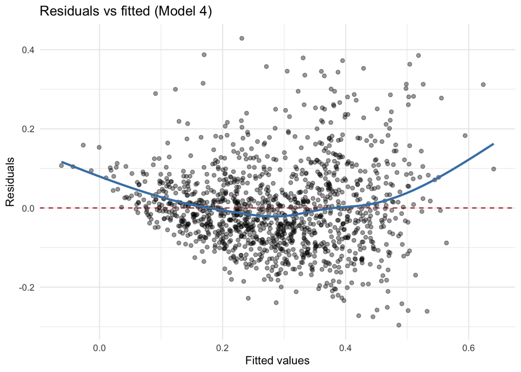

Figure 7: Model 4 diagnostic plots. Left: residuals vs. fitted values. Right: normal Q-Q plot of residuals.

```r
diag_df <- tibble(
  fitted = fitted(model4),
  resid  = resid(model4),
  rstud  = rstudent(model4)
)

p_resid <- ggplot(diag_df, aes(fitted, resid)) +
  geom_point(alpha = 0.4) +
  geom_hline(yintercept = 0, linetype = "dashed", colour = "firebrick") +
  geom_smooth(se = FALSE, colour = "steelblue") +
  labs(title = "Residuals vs fitted (Model 4)",
       x = "Fitted values", y = "Residuals") +
  theme_minimal()

p_qq <- ggplot(diag_df, aes(sample = resid)) +
  stat_qq(alpha = 0.4) +
  stat_qq_line(colour = "firebrick") +
  labs(title = "Q-Q plot of residuals (Model 4)",
       x = "Theoretical quantiles", y = "Sample quantiles") +
  theme_minimal()

p_resid
```

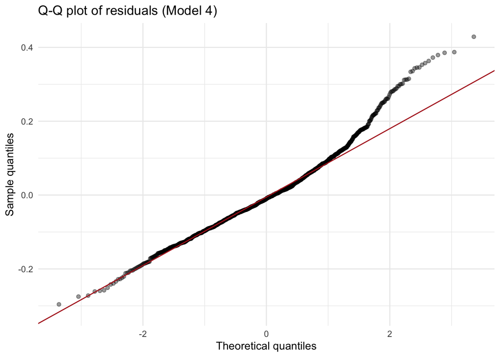

Figure 7: Model 4 diagnostic plots. Left: residuals vs. fitted values. Right: normal Q-Q plot of residuals.

```r
p_qq
```

```r
n_outliers <- sum(abs(diag_df$rstud) > 3, na.rm = TRUE)
```

## Limitations

Several limitations must be acknowledged. First, the analysis operates at the municipal aggregate level, meaning observed associations between income and renewable heating adoption cannot be attributed to individual households. The relevant financial capacity for the heating investment decision is that of the building owner, not the average municipal resident. Second, the GWR heating entries are of limited reliability: as shown in Figure 1, approximately 50% of building entries are flagged as low quality. Third, the analysis does not account for cantonal subsidy heterogeneity beyond the fixed effects included in the model.

## Conclusion

This project investigated whether municipal-level taxable income predicts the share of buildings equipped with renewable heating systems across Swiss municipalities, using the Federal Building and Dwellings Register (GWR) and ESTV income data. The headline finding is the opposite of the project’s starting hypothesis. After joining both sources at the BFS municipality level and adjusting for GWR data quality, building stock structure, municipal size, and cantonal fixed effects, a statistically significant *negative* association is observed: higher-income municipalities tend to have *lower* renewable heating shares. In the most complete specification (Model 4), the coefficient on `log_income` is -0.173, which implies that a 2.7-fold increase in mean taxable income corresponds to a roughly 17-percentage-point lower renewable heating share, holding the controls constant. The negative direction is robust to all four specifications and to including district heating in the renewable definition.

The most plausible explanation is structural rather than financial, and is consistent with the spatial pattern visible in Figures 5 and 6. The income distribution across Swiss municipalities is dominated by an urban-rural gradient: the highest-income municipalities are concentrated in the Zürich-Zug axis and around the Genfersee, while the lowest-income municipalities are largely Alpine. Urban municipalities tend to have a higher share of multi-family buildings, older protected stock in city centres, and district heating infrastructure (excluded from the primary renewable definition), all of which structurally depress the share of buildings on individually installed renewable systems. Rural and Alpine municipalities, by contrast, have a long tradition of wood heating and a larger single-family-house share, both of which lift the renewable share. The municipal-level income coefficient therefore captures urban-rural sorting more than it captures household financial capacity, and the result is an aggregate-level (ecological) effect that should not be read as a household-level claim. A wealthy household within an urban municipality may well be more likely to install a heat pump than its poorer neighbour, but that within-household pattern is not what the municipal aggregation measures.

From a policy perspective, the finding implies that the income-renewable gradient is the *wrong* axis on which to target subsidies. Means-tested subsidies aimed at low-income households would, given this evidence, be directed at municipalities that already have higher renewable shares, while urban high-income municipalities (where renewable adoption is structurally lower) would need a different policy instrument altogether: support for collective heat-pump installations in multi-family buildings, retrofit subsidies for historic stock, and integration with district heating decarbonisation programmes. The implication is not that wealth is irrelevant, but that the policy lever sits at the building-type and urban-form level, not at the income level.

Future work should combine individual building-level panel data with cantonal subsidy amounts as a continuous covariate, and apply spatial autoregressive models to account for the spatial clustering of adoption visible in the choropleth maps. A targeted re-survey of low-quality GWR entries in a representative sample of municipalities would also substantially improve the credibility of any quantitative claim about the income gradient.

## Additional Chapter: Cantonal Deep-Dive (Optional)

*This chapter is optional and provides an exploratory deep-dive into three cantons known to maintain high GWR data quality: Luzern (LU), Basel-Landschaft (BL), and Basel-Stadt (BS). The motivation is that the income-renewable relationship may be estimated more cleanly in these cantons, where heating entries are more reliable.*

### A1: Data Quality Profile of LU, BL, BS vs. Switzerland

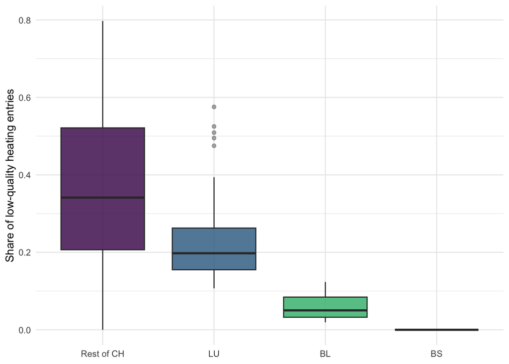

Figure 8: Distribution of the share of low-quality heating entries by group. Lower values indicate better data quality. LU, BL, and BS are compared to the rest of Switzerland.

```r
focus_cantons <- c("LU", "BL", "BS")

df_box <- df %>%
  mutate(group = case_when(
    canton %in% focus_cantons ~ canton,
    TRUE                      ~ "Rest of CH"
  )) %>%
  mutate(group = factor(group, levels = c("Rest of CH", "LU", "BL", "BS")))
# `df_box` adds a grouping variable for the boxplot.

p_bonus1 <- ggplot(df_box, aes(x = group, y = low_quality_share, fill = group)) +
  geom_boxplot(alpha = 0.8, outlier.alpha = 0.4) +
  scale_fill_viridis_d() +
  labs(x = NULL, y = "Share of low-quality heating entries") +
  theme_minimal() +
  theme(legend.position = "none")
p_bonus1
```

The boxplot allows a visual comparison of GWR data quality across the four groups. The three focus cantons should display systematically lower medians and tighter interquartile ranges than the rest of Switzerland if the premise of cleaner cantonal record-keeping holds.

### A2: Income-Renewable Relationship in Focus Cantons

```r
df_focus <- df %>% filter(canton %in% focus_cantons)
# `df_focus` is the LU/BL/BS subset for the focused regression.

model_bonus <- lm(renewable_share ~ log_income + low_quality_share +
                    sfh_share + pre1980_share,
                  data = df_focus)

focus_row <- tidy(model_bonus) %>%
  filter(term == "log_income") %>%
  transmute(
    Model       = "Focus cantons only (LU/BL/BS, Model 2)",
    `Beta`      = estimate,
    SE          = std.error,
    `p-value`   = fmt_p(p.value),
    `R-squared` = glance(model_bonus)$r.squared
  )

knitr::kable(
  bind_rows(extract_income(model2, "National (Model 2)"), focus_row),
  digits = 4,
  caption = "Table 4: Income coefficient in the national Model 2 vs. the focus-canton subset."
)
```

Table 4: Income coefficient in the national Model 2 vs. the focus-canton subset.

| Model | Beta | SE | p-value | R-squared |
| --- | --- | --- | --- | --- |
| National (Model 2) | -0.2930 | 0.0200 | <0.001 *** | 0.1701 |
| Focus cantons only (LU/BL/BS, Model 2) | -0.3071 | 0.0898 | 0.001 ** | 0.2882 |

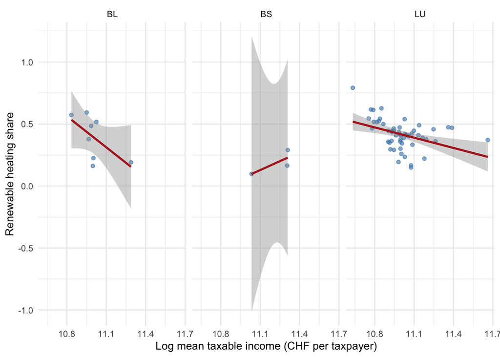

Figure 9: Renewable heating share vs. log mean taxable income, faceted by focus canton (LU, BL, BS). Each dot is one municipality; the red line is an OLS fit within canton.

```r
p_bonus2 <- ggplot(df_focus, aes(x = log_income, y = renewable_share)) +
  geom_point(alpha = 0.6, colour = "steelblue") +
  geom_smooth(method = "lm", se = TRUE, colour = "firebrick") +
  facet_wrap(~ canton) +
  labs(x = "Log mean taxable income (CHF per taxpayer)",
       y = "Renewable heating share") +
  theme_minimal()
p_bonus2
```

The focus-canton regression estimates the relationship in a subsample with structurally better GWR data quality. The focus-canton coefficient (-0.307) is in fact slightly *more negative* than the national one (-0.293), which is consistent with attenuation by data noise in the full sample: with cleaner records, the negative income gradient is a touch sharper, not softer. The faceted scatter plot lets the same pattern be inspected canton by canton.

### A3: Analogue Canton Identification

```r
# Canton-level medians on observable structural dimensions.
canton_profile <- df %>%
  group_by(canton) %>%
  summarise(
    sfh_med        = median(sfh_share,        na.rm = TRUE),
    pre1980_med    = median(pre1980_share,    na.rm = TRUE),
    log_income_med = median(log_income,       na.rm = TRUE),
    lowqual_med    = median(low_quality_share, na.rm = TRUE),
    .groups = "drop"
  )

# Standardise each column (z-scores) so dimensions are comparable.
profile_mat <- as.matrix(canton_profile[, -1])
profile_mat <- scale(profile_mat)
rownames(profile_mat) <- canton_profile$canton

dist_mat <- as.matrix(dist(profile_mat, method = "euclidean"))
# `dist_mat` is a square matrix of pairwise z-score distances between cantons.

# For each focus canton, list the top 5 nearest neighbours (excluding itself
# and the other two focus cantons).
nearest_table <- bind_rows(lapply(focus_cantons, function(fc) {
  dists <- dist_mat[fc, ]
  others <- dists[!names(dists) %in% c(fc)]
  top5   <- sort(others)[1:5]
  tibble(
    `Focus canton`       = fc,
    `Nearest neighbour`  = names(top5),
    `Distance (z-score)` = as.numeric(top5)
  )
}))

knitr::kable(nearest_table, digits = 3,
             caption = "Table 5: Top 5 structurally nearest cantons to each focus canton, by Euclidean distance in z-score space.")
```

Table 5: Top 5 structurally nearest cantons to each focus canton, by Euclidean distance in z-score space.

| Focus canton | Nearest neighbour | Distance (z-score) |
| --- | --- | --- |
| LU | BE | 1.034 |
| LU | FR | 1.171 |
| LU | NE | 1.248 |
| LU | UR | 1.483 |
| LU | SZ | 1.509 |
| BL | VD | 1.380 |
| BL | TI | 1.640 |
| BL | TG | 1.907 |
| BL | SH | 1.950 |
| BL | SG | 2.034 |
| BS | TI | 2.327 |
| BS | VD | 2.437 |
| BS | BL | 2.656 |
| BS | ZH | 2.968 |
| BS | GE | 3.121 |

```r
# Closest one analogue per focus canton (excluding the other focus cantons),
# pooled into a unique set for the joint regression.
analogues <- unique(unlist(lapply(focus_cantons, function(fc) {
  d <- dist_mat[fc, ]
  d <- d[!names(d) %in% focus_cantons]
  names(sort(d))[1]
})))

df_focus_plus <- df %>% filter(canton %in% c(focus_cantons, analogues))

model_bonus_plus <- lm(renewable_share ~ log_income + low_quality_share +
                         sfh_share + pre1980_share,
                       data = df_focus_plus)

comparison <- bind_rows(
  extract_income(model2, "National (Model 2)"),
  tidy(model_bonus) %>%
    filter(term == "log_income") %>%
    transmute(Model       = "Focus cantons only",
              `Beta`      = estimate,
              SE          = std.error,
              `p-value`   = fmt_p(p.value),
              `R-squared` = glance(model_bonus)$r.squared),
  tidy(model_bonus_plus) %>%
    filter(term == "log_income") %>%
    transmute(Model       = sprintf("Focus + analogues (%s)",
                                     paste(analogues, collapse = ", ")),
              `Beta`      = estimate,
              SE          = std.error,
              `p-value`   = fmt_p(p.value),
              `R-squared` = glance(model_bonus_plus)$r.squared)
)
# `comparison` lines up the income coefficient across three nested samples.

knitr::kable(comparison, digits = 4,
             caption = "Table 6: Income coefficient comparison across national, focus-canton-only, and focus-plus-analogue samples (all using Model 2 specification).")
```

Table 6: Income coefficient comparison across national, focus-canton-only, and focus-plus-analogue samples (all using Model 2 specification).

| Model | Beta | SE | p-value | R-squared |
| --- | --- | --- | --- | --- |
| National (Model 2) | -0.2930 | 0.0200 | <0.001 *** | 0.1701 |
| Focus cantons only | -0.3071 | 0.0898 | 0.001 ** | 0.2882 |
| Focus + analogues (BE, VD, TI) | -0.2514 | 0.0286 | <0.001 *** | 0.4223 |